# Risk Factor Analysis

## Outcome Variable

**Outcome Variable:** haz

## Predictor Variables

**Intervention Variable:** mwtkg

**Adjustment Set:**

- arm
- W_mage
- meducyrs
- feducyrs
- hhwealth_quart
- W_nrooms
- brthmon
- W_parity
- impfloor
- impsan
- safeh20
- delta_W_mage
- delta_meducyrs
- delta_feducyrs
- delta_hhwealth_quart
- delta_W_nrooms
- delta_brthmon
- delta_W_parity
- delta_impfloor
- delta_impsan
- delta_safeh20

## Stratifying Variables

The analysis was stratified on these variable(s):

- agecat
- studyid
- country

## Data Summary

| agecat | studyid | country | mwtkg | n_cell | n |
| --- | --- | --- | --- | --- | --- |
| Birth | ki0047075b-MAL-ED | BANGLADESH | >=58 kg | 38 | 222 |
| Birth | ki0047075b-MAL-ED | BANGLADESH | <52 kg | 143 | 222 |
| Birth | ki0047075b-MAL-ED | BANGLADESH | [52-58) kg | 41 | 222 |
| Birth | ki0047075b-MAL-ED | BRAZIL | >=58 kg | 34 | 64 |
| Birth | ki0047075b-MAL-ED | BRAZIL | <52 kg | 15 | 64 |
| Birth | ki0047075b-MAL-ED | BRAZIL | [52-58) kg | 15 | 64 |
| Birth | ki0047075b-MAL-ED | INDIA | >=58 kg | 6 | 43 |
| Birth | ki0047075b-MAL-ED | INDIA | <52 kg | 29 | 43 |
| Birth | ki0047075b-MAL-ED | INDIA | [52-58) kg | 8 | 43 |
| Birth | ki0047075b-MAL-ED | NEPAL | >=58 kg | 9 | 27 |
| Birth | ki0047075b-MAL-ED | NEPAL | <52 kg | 8 | 27 |
| Birth | ki0047075b-MAL-ED | NEPAL | [52-58) kg | 10 | 27 |
| Birth | ki0047075b-MAL-ED | PERU | >=58 kg | 83 | 226 |
| Birth | ki0047075b-MAL-ED | PERU | <52 kg | 84 | 226 |
| Birth | ki0047075b-MAL-ED | PERU | [52-58) kg | 59 | 226 |
| Birth | ki0047075b-MAL-ED | SOUTH AFRICA | >=58 kg | 69 | 101 |
| Birth | ki0047075b-MAL-ED | SOUTH AFRICA | <52 kg | 10 | 101 |
| Birth | ki0047075b-MAL-ED | SOUTH AFRICA | [52-58) kg | 22 | 101 |
| Birth | ki0047075b-MAL-ED | TANZANIA, UNITED REPUBLIC OF | >=58 kg | 47 | 122 |
| Birth | ki0047075b-MAL-ED | TANZANIA, UNITED REPUBLIC OF | <52 kg | 45 | 122 |
| Birth | ki0047075b-MAL-ED | TANZANIA, UNITED REPUBLIC OF | [52-58) kg | 30 | 122 |
| Birth | ki1000304b-SAS-CompFeed | INDIA | >=58 kg | 91 | 1236 |
| Birth | ki1000304b-SAS-CompFeed | INDIA | <52 kg | 949 | 1236 |
| Birth | ki1000304b-SAS-CompFeed | INDIA | [52-58) kg | 196 | 1236 |
| Birth | ki1017093-NIH-Birth | BANGLADESH | >=58 kg | 80 | 608 |
| Birth | ki1017093-NIH-Birth | BANGLADESH | <52 kg | 441 | 608 |
| Birth | ki1017093-NIH-Birth | BANGLADESH | [52-58) kg | 87 | 608 |
| Birth | ki1017093b-PROVIDE | BANGLADESH | >=58 kg | 91 | 517 |
| Birth | ki1017093b-PROVIDE | BANGLADESH | <52 kg | 330 | 517 |
| Birth | ki1017093b-PROVIDE | BANGLADESH | [52-58) kg | 96 | 517 |

[output cut: 105 more lines]

The following strata were considered:

- agecat: 24 months, studyid: ki0047075b-MAL-ED, country: BANGLADESH
- agecat: 24 months, studyid: ki0047075b-MAL-ED, country: BRAZIL
- agecat: 24 months, studyid: ki0047075b-MAL-ED, country: INDIA
- agecat: 24 months, studyid: ki0047075b-MAL-ED, country: NEPAL
- agecat: 24 months, studyid: ki0047075b-MAL-ED, country: PERU
- agecat: 24 months, studyid: ki0047075b-MAL-ED, country: SOUTH AFRICA
- agecat: 24 months, studyid: ki0047075b-MAL-ED, country: TANZANIA, UNITED REPUBLIC OF
- agecat: 24 months, studyid: ki1017093-NIH-Birth, country: BANGLADESH
- agecat: 24 months, studyid: ki1017093b-PROVIDE, country: BANGLADESH
- agecat: 24 months, studyid: ki1017093c-NIH-Crypto, country: BANGLADESH
- agecat: 24 months, studyid: ki1066203-TanzaniaChild2, country: TANZANIA, UNITED REPUBLIC OF
- agecat: 24 months, studyid: ki1119695-PROBIT, country: BELARUS
- agecat: 24 months, studyid: ki1126311-ZVITAMBO, country: ZIMBABWE
- agecat: 24 months, studyid: ki1148112-LCNI-5, country: MALAWI
- agecat: 24 months, studyid: kiGH5241-JiVitA-3, country: BANGLADESH
- agecat: 6 months, studyid: ki0047075b-MAL-ED, country: BANGLADESH
- agecat: 6 months, studyid: ki0047075b-MAL-ED, country: BRAZIL
- agecat: 6 months, studyid: ki0047075b-MAL-ED, country: INDIA
- agecat: 6 months, studyid: ki0047075b-MAL-ED, country: NEPAL
- agecat: 6 months, studyid: ki0047075b-MAL-ED, country: PERU
- agecat: 6 months, studyid: ki0047075b-MAL-ED, country: SOUTH AFRICA
- agecat: 6 months, studyid: ki0047075b-MAL-ED, country: TANZANIA, UNITED REPUBLIC OF
- agecat: 6 months, studyid: ki1000304b-SAS-CompFeed, country: INDIA
- agecat: 6 months, studyid: ki1017093-NIH-Birth, country: BANGLADESH
- agecat: 6 months, studyid: ki1017093b-PROVIDE, country: BANGLADESH
- agecat: 6 months, studyid: ki1017093c-NIH-Crypto, country: BANGLADESH
- agecat: 6 months, studyid: ki1066203-TanzaniaChild2, country: TANZANIA, UNITED REPUBLIC OF
- agecat: 6 months, studyid: ki1119695-PROBIT, country: BELARUS
- agecat: 6 months, studyid: ki1126311-ZVITAMBO, country: ZIMBABWE
- agecat: 6 months, studyid: ki1148112-LCNI-5, country: MALAWI
- agecat: 6 months, studyid: kiGH5241-JiVitA-3, country: BANGLADESH
- agecat: Birth, studyid: ki0047075b-MAL-ED, country: BANGLADESH
- agecat: Birth, studyid: ki0047075b-MAL-ED, country: BRAZIL
- agecat: Birth, studyid: ki0047075b-MAL-ED, country: INDIA
- agecat: Birth, studyid: ki0047075b-MAL-ED, country: NEPAL
- agecat: Birth, studyid: ki0047075b-MAL-ED, country: PERU
- agecat: Birth, studyid: ki0047075b-MAL-ED, country: SOUTH AFRICA
- agecat: Birth, studyid: ki0047075b-MAL-ED, country: TANZANIA, UNITED REPUBLIC OF
- agecat: Birth, studyid: ki1000304b-SAS-CompFeed, country: INDIA
- agecat: Birth, studyid: ki1017093-NIH-Birth, country: BANGLADESH
- agecat: Birth, studyid: ki1017093b-PROVIDE, country: BANGLADESH
- agecat: Birth, studyid: ki1017093c-NIH-Crypto, country: BANGLADESH
- agecat: Birth, studyid: ki1119695-PROBIT, country: BELARUS
- agecat: Birth, studyid: ki1126311-ZVITAMBO, country: ZIMBABWE
- agecat: Birth, studyid: kiGH5241-JiVitA-3, country: BANGLADESH

### Dropped Strata

Some strata were dropped due to rare outcomes:

- agecat: 24 months, studyid: ki1066203-TanzaniaChild2, country: TANZANIA, UNITED REPUBLIC OF

## Methods Detail

We’re interested in the causal parameters $E[Y_a]$ for all values of $a \in \mathcal{A}$. These parameters represent the mean outcome if, possibly contrary to fact, we intervened to set all units to have $A=a$. Under the randomization and positivity assumptions, these are identified by the statistical parameters $\psi_a=E_W[E_{Y|A,W}(Y|A=a,W)]$. In addition, we’re interested in the mean of $Y$, $E[Y]$ under no intervention (the observed mean). We will estimate these parameters by using SuperLearner to fit the relevant likelihood factors – $E_{Y|A,W}(Y|A=a,W)$ and $p(A=a|W)$, and then updating our likelihood fit using a joint TMLE.

For unadjusted analyses ($W=\{\}$), initial likelihoods were estimated using Lrnr_glm to estimate the simple $E(Y|A)$ and Lrnr_mean to estimate $p(A)$. For adjusted analyses, a small library containing Lrnr_glmnet, Lrnr_xgboost, and Lrnr_mean was used.

Having estimated these parameters, we will then use the delta method to estimate relative risks and attributable risks relative to a prespecified baseline level of $A$.

# Results Detail

## Results Plots

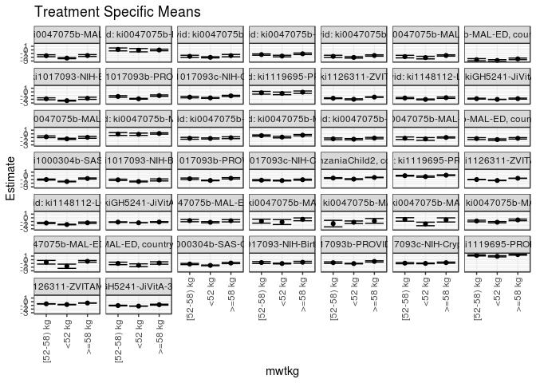

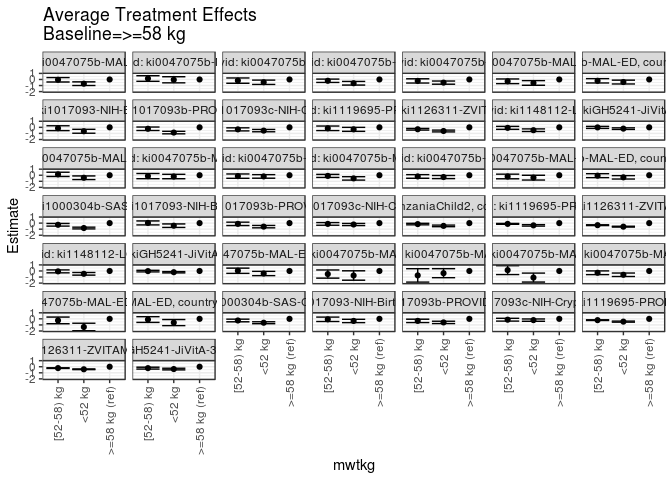

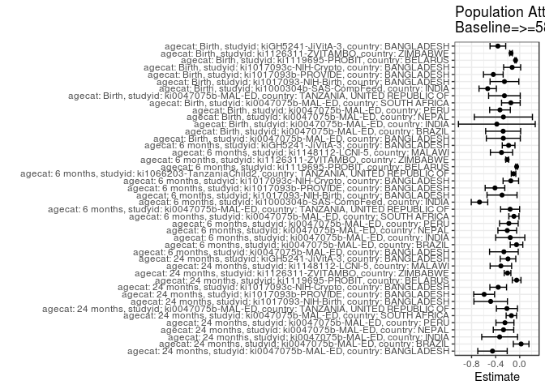

## Results Table

### Parameter: TSM

| agecat | studyid | country | intervention_level | baseline_level | estimate | ci_lower | ci_upper |
| --- | --- | --- | --- | --- | --- | --- | --- |
| Birth | ki0047075b-MAL-ED | BANGLADESH | >=58 kg | NA | -0.8055209 | -1.1140205 | -0.4970213 |
| Birth | ki0047075b-MAL-ED | BANGLADESH | <52 kg | NA | -1.2213950 | -1.3897230 | -1.0530670 |
| Birth | ki0047075b-MAL-ED | BANGLADESH | [52-58) kg | NA | -0.7672942 | -1.0677587 | -0.4668298 |
| Birth | ki0047075b-MAL-ED | BRAZIL | >=58 kg | NA | -0.4132351 | -0.7957675 | -0.0307028 |
| Birth | ki0047075b-MAL-ED | BRAZIL | <52 kg | NA | -1.1579320 | -1.8183200 | -0.4975440 |
| Birth | ki0047075b-MAL-ED | BRAZIL | [52-58) kg | NA | -0.9188604 | -1.4552119 | -0.3825089 |
| Birth | ki0047075b-MAL-ED | INDIA | >=58 kg | NA | -0.8500000 | -1.5073907 | -0.1926093 |
| Birth | ki0047075b-MAL-ED | INDIA | <52 kg | NA | -1.2131034 | -1.5635569 | -0.8626500 |
| Birth | ki0047075b-MAL-ED | INDIA | [52-58) kg | NA | -1.5775000 | -2.4667124 | -0.6882876 |
| Birth | ki0047075b-MAL-ED | NEPAL | >=58 kg | NA | -0.5822222 | -1.1447657 | -0.0196787 |
| Birth | ki0047075b-MAL-ED | NEPAL | <52 kg | NA | -1.6712500 | -2.1476338 | -1.1948662 |
| Birth | ki0047075b-MAL-ED | NEPAL | [52-58) kg | NA | -0.4430000 | -0.9133974 | 0.0273974 |
| Birth | ki0047075b-MAL-ED | PERU | >=58 kg | NA | -0.5772066 | -0.7948068 | -0.3596063 |
| Birth | ki0047075b-MAL-ED | PERU | <52 kg | NA | -1.2026765 | -1.3818829 | -1.0234701 |
| Birth | ki0047075b-MAL-ED | PERU | [52-58) kg | NA | -0.8695702 | -1.0833952 | -0.6557453 |
| Birth | ki0047075b-MAL-ED | SOUTH AFRICA | >=58 kg | NA | -0.4237999 | -0.6512042 | -0.1963957 |
| Birth | ki0047075b-MAL-ED | SOUTH AFRICA | <52 kg | NA | -1.7617306 | -2.3326681 | -1.1907932 |
| Birth | ki0047075b-MAL-ED | SOUTH AFRICA | [52-58) kg | NA | -0.6773172 | -1.1726573 | -0.1819771 |
| Birth | ki0047075b-MAL-ED | TANZANIA, UNITED REPUBLIC OF | >=58 kg | NA | -0.8824481 | -1.2063519 | -0.5585442 |
| Birth | ki0047075b-MAL-ED | TANZANIA, UNITED REPUBLIC OF | <52 kg | NA | -1.4961781 | -1.8770062 | -1.1153500 |
| Birth | ki0047075b-MAL-ED | TANZANIA, UNITED REPUBLIC OF | [52-58) kg | NA | -0.9968415 | -1.3341637 | -0.6595193 |
| Birth | ki1000304b-SAS-CompFeed | INDIA | >=58 kg | NA | -0.8898972 | -1.0530403 | -0.7267541 |
| Birth | ki1000304b-SAS-CompFeed | INDIA | <52 kg | NA | -1.5281036 | -1.6181723 | -1.4380348 |
| Birth | ki1000304b-SAS-CompFeed | INDIA | [52-58) kg | NA | -1.1572862 | -1.3208097 | -0.9937627 |
| Birth | ki1017093-NIH-Birth | BANGLADESH | >=58 kg | NA | -0.6773621 | -0.9309739 | -0.4237503 |
| Birth | ki1017093-NIH-Birth | BANGLADESH | <52 kg | NA | -1.0233566 | -1.1268381 | -0.9198751 |
| Birth | ki1017093-NIH-Birth | BANGLADESH | [52-58) kg | NA | -0.7518029 | -1.0107549 | -0.4928509 |
| Birth | ki1017093b-PROVIDE | BANGLADESH | >=58 kg | NA | -0.4538520 | -0.6291080 | -0.2785959 |
| Birth | ki1017093b-PROVIDE | BANGLADESH | <52 kg | NA | -1.0380621 | -1.1214917 | -0.9546325 |
| Birth | ki1017093b-PROVIDE | BANGLADESH | [52-58) kg | NA | -0.7885208 | -1.0050929 | -0.5719486 |

[output cut: 102 more lines]

### Parameter: E(Y)

| agecat | studyid | country | intervention_level | baseline_level | estimate | ci_lower | ci_upper |
| --- | --- | --- | --- | --- | --- | --- | --- |
| Birth | ki0047075b-MAL-ED | BANGLADESH | NA | NA | -1.0778829 | -1.2122580 | -0.9435077 |
| Birth | ki0047075b-MAL-ED | BRAZIL | NA | NA | -0.6884375 | -0.9678371 | -0.4090379 |
| Birth | ki0047075b-MAL-ED | INDIA | NA | NA | -1.2302326 | -1.5393614 | -0.9211037 |
| Birth | ki0047075b-MAL-ED | NEPAL | NA | NA | -0.8533333 | -1.2104864 | -0.4961803 |
| Birth | ki0047075b-MAL-ED | PERU | NA | NA | -0.9051327 | -1.0238686 | -0.7863969 |
| Birth | ki0047075b-MAL-ED | SOUTH AFRICA | NA | NA | -0.5707921 | -0.7685593 | -0.3730248 |
| Birth | ki0047075b-MAL-ED | TANZANIA, UNITED REPUBLIC OF | NA | NA | -1.1364754 | -1.3478823 | -0.9250686 |
| Birth | ki1000304b-SAS-CompFeed | INDIA | NA | NA | -1.4220793 | -1.5007856 | -1.3433730 |
| Birth | ki1017093-NIH-Birth | BANGLADESH | NA | NA | -0.9310197 | -1.0197391 | -0.8423003 |
| Birth | ki1017093b-PROVIDE | BANGLADESH | NA | NA | -0.8925145 | -0.9687201 | -0.8163089 |
| Birth | ki1017093c-NIH-Crypto | BANGLADESH | NA | NA | -0.9089163 | -0.9806324 | -0.8372002 |
| Birth | ki1119695-PROBIT | BELARUS | NA | NA | 1.3272020 | 1.1683762 | 1.4860279 |
| Birth | ki1126311-ZVITAMBO | ZIMBABWE | NA | NA | -0.4966839 | -0.5196015 | -0.4737663 |
| Birth | kiGH5241-JiVitA-3 | BANGLADESH | NA | NA | -1.1731789 | -1.2012047 | -1.1451532 |
| 6 months | ki0047075b-MAL-ED | BANGLADESH | NA | NA | -1.2054910 | -1.3228953 | -1.0880867 |
| 6 months | ki0047075b-MAL-ED | BRAZIL | NA | NA | 0.0532131 | -0.0914567 | 0.1978830 |
| 6 months | ki0047075b-MAL-ED | INDIA | NA | NA | -1.2058014 | -1.3242792 | -1.0873236 |
| 6 months | ki0047075b-MAL-ED | NEPAL | NA | NA | -0.5610593 | -0.6737915 | -0.4483272 |
| 6 months | ki0047075b-MAL-ED | PERU | NA | NA | -1.3285478 | -1.4371840 | -1.2199116 |
| 6 months | ki0047075b-MAL-ED | SOUTH AFRICA | NA | NA | -1.0733534 | -1.2031913 | -0.9435155 |
| 6 months | ki0047075b-MAL-ED | TANZANIA, UNITED REPUBLIC OF | NA | NA | -1.3687449 | -1.4907629 | -1.2467270 |
| 6 months | ki1000304b-SAS-CompFeed | INDIA | NA | NA | -1.4003907 | -1.4819787 | -1.3188027 |
| 6 months | ki1017093-NIH-Birth | BANGLADESH | NA | NA | -1.4073821 | -1.4960598 | -1.3187043 |
| 6 months | ki1017093b-PROVIDE | BANGLADESH | NA | NA | -1.0895301 | -1.1639589 | -1.0151013 |
| 6 months | ki1017093c-NIH-Crypto | BANGLADESH | NA | NA | -1.1986783 | -1.2700937 | -1.1272630 |
| 6 months | ki1066203-TanzaniaChild2 | TANZANIA, UNITED REPUBLIC OF | NA | NA | -0.5424765 | -0.5918460 | -0.4931071 |
| 6 months | ki1119695-PROBIT | BELARUS | NA | NA | 0.1143882 | 0.0212298 | 0.2075466 |
| 6 months | ki1126311-ZVITAMBO | ZIMBABWE | NA | NA | -0.8785195 | -0.9045379 | -0.8525011 |
| 6 months | ki1148112-LCNI-5 | MALAWI | NA | NA | -1.6584707 | -1.7281551 | -1.5887863 |
| 6 months | kiGH5241-JiVitA-3 | BANGLADESH | NA | NA | -1.3359824 | -1.3590645 | -1.3129004 |
| 24 months | ki0047075b-MAL-ED | BANGLADESH | NA | NA | -1.9789151 | -2.1055330 | -1.8522972 |
| 24 months | ki0047075b-MAL-ED | BRAZIL | NA | NA | 0.0069048 | -0.1627841 | 0.1765936 |
| 24 months | ki0047075b-MAL-ED | INDIA | NA | NA | -1.8831195 | -2.0084753 | -1.7577636 |
| 24 months | ki0047075b-MAL-ED | NEPAL | NA | NA | -1.3118640 | -1.4315132 | -1.1922149 |
| 24 months | ki0047075b-MAL-ED | PERU | NA | NA | -1.7544776 | -1.8753255 | -1.6336298 |
| 24 months | ki0047075b-MAL-ED | SOUTH AFRICA | NA | NA | -1.6474145 | -1.7842298 | -1.5105993 |
| 24 months | ki0047075b-MAL-ED | TANZANIA, UNITED REPUBLIC OF | NA | NA | -2.6451636 | -2.7802323 | -2.5100948 |
| 24 months | ki1017093-NIH-Birth | BANGLADESH | NA | NA | -2.2190579 | -2.3217459 | -2.1163699 |
| 24 months | ki1017093b-PROVIDE | BANGLADESH | NA | NA | -1.6002600 | -1.6836163 | -1.5169036 |
| 24 months | ki1017093c-NIH-Crypto | BANGLADESH | NA | NA | -1.4412646 | -1.5249156 | -1.3576135 |
| 24 months | ki1119695-PROBIT | BELARUS | NA | NA | -0.1312742 | -0.4286264 | 0.1660780 |
| 24 months | ki1126311-ZVITAMBO | ZIMBABWE | NA | NA | -1.6070497 | -1.6645093 | -1.5495902 |
| 24 months | ki1148112-LCNI-5 | MALAWI | NA | NA | -1.8854671 | -1.9666281 | -1.8043062 |
| 24 months | kiGH5241-JiVitA-3 | BANGLADESH | NA | NA | -2.0193528 | -2.0469684 | -1.9917372 |

### Parameter: ATE

| agecat | studyid | country | intervention_level | baseline_level | estimate | ci_lower | ci_upper |
| --- | --- | --- | --- | --- | --- | --- | --- |
| Birth | ki0047075b-MAL-ED | BANGLADESH | >=58 kg | >=58 kg | 0.0000000 | 0.0000000 | 0.0000000 |
| Birth | ki0047075b-MAL-ED | BANGLADESH | <52 kg | >=58 kg | -0.4158741 | -0.7679497 | -0.0637984 |
| Birth | ki0047075b-MAL-ED | BANGLADESH | [52-58) kg | >=58 kg | 0.0382267 | -0.3933775 | 0.4698308 |
| Birth | ki0047075b-MAL-ED | BRAZIL | >=58 kg | >=58 kg | 0.0000000 | 0.0000000 | 0.0000000 |
| Birth | ki0047075b-MAL-ED | BRAZIL | <52 kg | >=58 kg | -0.7446969 | -1.5188078 | 0.0294140 |
| Birth | ki0047075b-MAL-ED | BRAZIL | [52-58) kg | >=58 kg | -0.5056253 | -1.1776881 | 0.1664376 |
| Birth | ki0047075b-MAL-ED | INDIA | >=58 kg | >=58 kg | 0.0000000 | 0.0000000 | 0.0000000 |
| Birth | ki0047075b-MAL-ED | INDIA | <52 kg | >=58 kg | -0.3631034 | -1.1080734 | 0.3818665 |
| Birth | ki0047075b-MAL-ED | INDIA | [52-58) kg | >=58 kg | -0.7275000 | -1.8333306 | 0.3783306 |
| Birth | ki0047075b-MAL-ED | NEPAL | >=58 kg | >=58 kg | 0.0000000 | 0.0000000 | 0.0000000 |
| Birth | ki0047075b-MAL-ED | NEPAL | <52 kg | >=58 kg | -1.0890278 | -1.8261822 | -0.3518733 |
| Birth | ki0047075b-MAL-ED | NEPAL | [52-58) kg | >=58 kg | 0.1392222 | -0.5940778 | 0.8725223 |
| Birth | ki0047075b-MAL-ED | PERU | >=58 kg | >=58 kg | 0.0000000 | 0.0000000 | 0.0000000 |
| Birth | ki0047075b-MAL-ED | PERU | <52 kg | >=58 kg | -0.6254699 | -0.9095750 | -0.3413648 |
| Birth | ki0047075b-MAL-ED | PERU | [52-58) kg | >=58 kg | -0.2923637 | -0.6003578 | 0.0156305 |
| Birth | ki0047075b-MAL-ED | SOUTH AFRICA | >=58 kg | >=58 kg | 0.0000000 | 0.0000000 | 0.0000000 |
| Birth | ki0047075b-MAL-ED | SOUTH AFRICA | <52 kg | >=58 kg | -1.3379307 | -1.9559741 | -0.7198872 |
| Birth | ki0047075b-MAL-ED | SOUTH AFRICA | [52-58) kg | >=58 kg | -0.2535173 | -0.8034921 | 0.2964576 |
| Birth | ki0047075b-MAL-ED | TANZANIA, UNITED REPUBLIC OF | >=58 kg | >=58 kg | 0.0000000 | 0.0000000 | 0.0000000 |
| Birth | ki0047075b-MAL-ED | TANZANIA, UNITED REPUBLIC OF | <52 kg | >=58 kg | -0.6137301 | -1.1155841 | -0.1118761 |
| Birth | ki0047075b-MAL-ED | TANZANIA, UNITED REPUBLIC OF | [52-58) kg | >=58 kg | -0.1143935 | -0.5823450 | 0.3535581 |
| Birth | ki1000304b-SAS-CompFeed | INDIA | >=58 kg | >=58 kg | 0.0000000 | 0.0000000 | 0.0000000 |
| Birth | ki1000304b-SAS-CompFeed | INDIA | <52 kg | >=58 kg | -0.6382064 | -0.7974505 | -0.4789622 |
| Birth | ki1000304b-SAS-CompFeed | INDIA | [52-58) kg | >=58 kg | -0.2673890 | -0.4831308 | -0.0516472 |
| Birth | ki1017093-NIH-Birth | BANGLADESH | >=58 kg | >=58 kg | 0.0000000 | 0.0000000 | 0.0000000 |
| Birth | ki1017093-NIH-Birth | BANGLADESH | <52 kg | >=58 kg | -0.3459945 | -0.6207408 | -0.0712482 |
| Birth | ki1017093-NIH-Birth | BANGLADESH | [52-58) kg | >=58 kg | -0.0744408 | -0.4384296 | 0.2895480 |
| Birth | ki1017093b-PROVIDE | BANGLADESH | >=58 kg | >=58 kg | 0.0000000 | 0.0000000 | 0.0000000 |
| Birth | ki1017093b-PROVIDE | BANGLADESH | <52 kg | >=58 kg | -0.5842101 | -0.7783060 | -0.3901143 |
| Birth | ki1017093b-PROVIDE | BANGLADESH | [52-58) kg | >=58 kg | -0.3346688 | -0.6130087 | -0.0563288 |

[output cut: 102 more lines]

### Parameter: PAR

| agecat | studyid | country | intervention_level | baseline_level | estimate | ci_lower | ci_upper |
| --- | --- | --- | --- | --- | --- | --- | --- |
| Birth | ki0047075b-MAL-ED | BANGLADESH | >=58 kg | NA | -0.2723620 | -0.5547083 | 0.0099844 |
| Birth | ki0047075b-MAL-ED | BRAZIL | >=58 kg | NA | -0.2752024 | -0.5660432 | 0.0156385 |
| Birth | ki0047075b-MAL-ED | INDIA | >=58 kg | NA | -0.3802326 | -1.0182919 | 0.2578268 |
| Birth | ki0047075b-MAL-ED | NEPAL | >=58 kg | NA | -0.2711111 | -0.7538568 | 0.2116346 |
| Birth | ki0047075b-MAL-ED | PERU | >=58 kg | NA | -0.3279262 | -0.4993613 | -0.1564910 |
| Birth | ki0047075b-MAL-ED | SOUTH AFRICA | >=58 kg | NA | -0.1469921 | -0.3017844 | 0.0078001 |
| Birth | ki0047075b-MAL-ED | TANZANIA, UNITED REPUBLIC OF | >=58 kg | NA | -0.2540274 | -0.5168132 | 0.0087585 |
| Birth | ki1000304b-SAS-CompFeed | INDIA | >=58 kg | NA | -0.5321821 | -0.6762389 | -0.3881253 |
| Birth | ki1017093-NIH-Birth | BANGLADESH | >=58 kg | NA | -0.2536576 | -0.4925350 | -0.0147802 |
| Birth | ki1017093b-PROVIDE | BANGLADESH | >=58 kg | NA | -0.4386625 | -0.6018529 | -0.2754721 |
| Birth | ki1017093c-NIH-Crypto | BANGLADESH | >=58 kg | NA | -0.1259036 | -0.2675476 | 0.0157404 |
| Birth | ki1119695-PROBIT | BELARUS | >=58 kg | NA | -0.0694830 | -0.0807513 | -0.0582147 |
| Birth | ki1126311-ZVITAMBO | ZIMBABWE | >=58 kg | NA | -0.1445198 | -0.1669106 | -0.1221290 |
| Birth | kiGH5241-JiVitA-3 | BANGLADESH | >=58 kg | NA | -0.3628791 | -0.4931992 | -0.2325591 |
| 6 months | ki0047075b-MAL-ED | BANGLADESH | >=58 kg | NA | -0.2631524 | -0.5014449 | -0.0248598 |
| 6 months | ki0047075b-MAL-ED | BRAZIL | >=58 kg | NA | -0.0532041 | -0.1577541 | 0.0513460 |
| 6 months | ki0047075b-MAL-ED | INDIA | >=58 kg | NA | -0.1572367 | -0.3991610 | 0.0846876 |
| 6 months | ki0047075b-MAL-ED | NEPAL | >=58 kg | NA | -0.2068083 | -0.3623415 | -0.0512750 |
| 6 months | ki0047075b-MAL-ED | PERU | >=58 kg | NA | -0.1804887 | -0.3352700 | -0.0257074 |
| 6 months | ki0047075b-MAL-ED | SOUTH AFRICA | >=58 kg | NA | -0.0963294 | -0.1803664 | -0.0122924 |
| 6 months | ki0047075b-MAL-ED | TANZANIA, UNITED REPUBLIC OF | >=58 kg | NA | -0.1594967 | -0.3174311 | -0.0015623 |
| 6 months | ki1000304b-SAS-CompFeed | INDIA | >=58 kg | NA | -0.6683274 | -0.8053865 | -0.5312682 |
| 6 months | ki1017093-NIH-Birth | BANGLADESH | >=58 kg | NA | -0.2939835 | -0.5433863 | -0.0445807 |
| 6 months | ki1017093b-PROVIDE | BANGLADESH | >=58 kg | NA | -0.4111766 | -0.5741377 | -0.2482156 |
| 6 months | ki1017093c-NIH-Crypto | BANGLADESH | >=58 kg | NA | -0.1475393 | -0.2765717 | -0.0185069 |
| 6 months | ki1066203-TanzaniaChild2 | TANZANIA, UNITED REPUBLIC OF | >=58 kg | NA | -0.1025864 | -0.1404869 | -0.0646859 |
| 6 months | ki1119695-PROBIT | BELARUS | >=58 kg | NA | -0.0511509 | -0.0662064 | -0.0360955 |
| 6 months | ki1126311-ZVITAMBO | ZIMBABWE | >=58 kg | NA | -0.2080579 | -0.2331333 | -0.1829825 |
| 6 months | ki1148112-LCNI-5 | MALAWI | >=58 kg | NA | -0.3026121 | -0.4872655 | -0.1179587 |
| 6 months | kiGH5241-JiVitA-3 | BANGLADESH | >=58 kg | NA | -0.1846879 | -0.2903107 | -0.0790650 |
| 24 months | ki0047075b-MAL-ED | BANGLADESH | >=58 kg | NA | -0.4524590 | -0.6969710 | -0.2079471 |
| 24 months | ki0047075b-MAL-ED | BRAZIL | >=58 kg | NA | 0.0235680 | -0.1061098 | 0.1532458 |
| 24 months | ki0047075b-MAL-ED | INDIA | >=58 kg | NA | -0.3336165 | -0.6313071 | -0.0359259 |
| 24 months | ki0047075b-MAL-ED | NEPAL | >=58 kg | NA | -0.2693201 | -0.4395002 | -0.0991400 |
| 24 months | ki0047075b-MAL-ED | PERU | >=58 kg | NA | -0.2454903 | -0.3948346 | -0.0961461 |
| 24 months | ki0047075b-MAL-ED | SOUTH AFRICA | >=58 kg | NA | -0.1387528 | -0.2258376 | -0.0516680 |
| 24 months | ki0047075b-MAL-ED | TANZANIA, UNITED REPUBLIC OF | >=58 kg | NA | -0.2126521 | -0.3875787 | -0.0377255 |
| 24 months | ki1017093-NIH-Birth | BANGLADESH | >=58 kg | NA | -0.4825970 | -0.7609997 | -0.2041943 |
| 24 months | ki1017093b-PROVIDE | BANGLADESH | >=58 kg | NA | -0.5908483 | -0.7640468 | -0.4176498 |
| 24 months | ki1017093c-NIH-Crypto | BANGLADESH | >=58 kg | NA | -0.3574000 | -0.4959489 | -0.2188510 |
| 24 months | ki1119695-PROBIT | BELARUS | >=58 kg | NA | -0.0514204 | -0.1237606 | 0.0209198 |
| 24 months | ki1126311-ZVITAMBO | ZIMBABWE | >=58 kg | NA | -0.2024603 | -0.2581851 | -0.1467354 |
| 24 months | ki1148112-LCNI-5 | MALAWI | >=58 kg | NA | -0.3130560 | -0.4917513 | -0.1343608 |
| 24 months | kiGH5241-JiVitA-3 | BANGLADESH | >=58 kg | NA | -0.1948811 | -0.3244425 | -0.0653197 |